# Kĺzavé priemery

Dáta v súbore cmort.dat predstavujú priemernú dennú úmrtnosť na kardiovaskulárne ochorenia v najväčšom americkom okrese “Los Angeles county” s 10 mil. obyvateľov zaznamenávané týždenne za roky 1970-1979.

#### Načítanie dát

```r
cmort <- read.table("cmort.dat")
str(cmort)
```

```
## 'data.frame':    508 obs. of  1 variable:
##  $ V1: num  97.8 104.6 94.4 98 95.8 ...
```

```r
mortality<-cmort$V1
```

#### Zobrazenie dát ako ČR

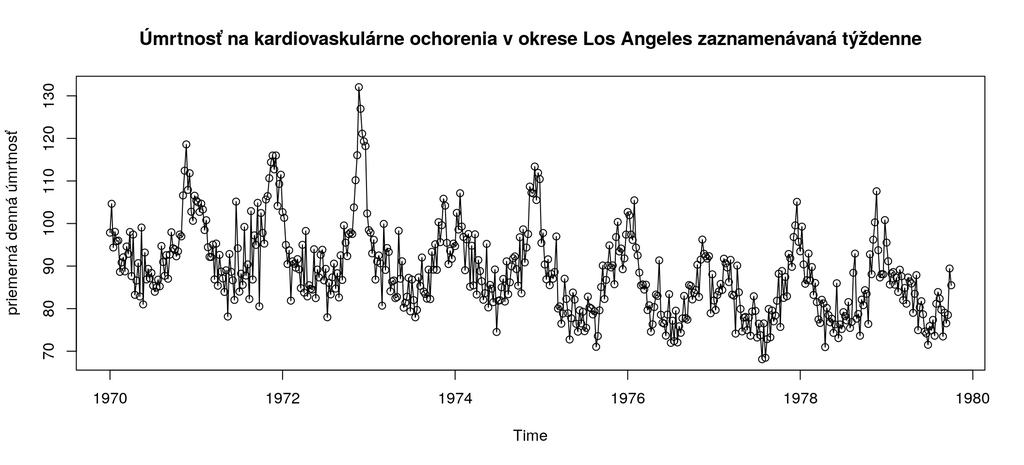

```r
mortalityTS<-ts(mortality, start = 1970, frequency = 52)
plot(mortalityTS, type = "o", main="Úmrtnosť na kardiovaskulárne ochorenia v okrese Los Angeles zaznamenávaná týždenne", ylab = "priemerná denná úmrtnosť")
```

Frekencia 52 lebo na rok pripadá 52 týždňov.

#### Pozorovanie

- klesajúci trend
- silná sezónna zložka - maximá v zime
- ustálená variability

#### Úloha

Vyrovnať dáta špeciálnym lineárnym filtrom, ktorý nazývame kĺzavý priemer:
$$\psi(B) = \sum_{j=-\infty}^{+\infty} \psi_jB^j$$
Ten aplikujeme na $Y_t$ Kĺzavé priemery môžu byť definované aj inak.
$$X_t = \sum_{j=-\infty}^{+\infty} \psi_jY_{t-j}$$
Ak rovnaké váhy, tak kĺzavy priemer:
$$X_t = \frac{1}{2q+1}\sum_{j=-\infty}^{+\infty}Y_{t-j}$$
, $q\in N$

Aplikovanie filtra:

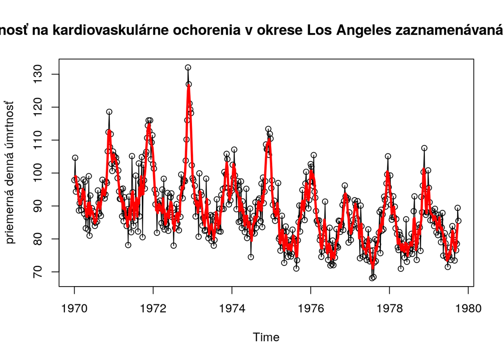

```r
klzavyPriemerKP3 <- filter(mortalityTS, filter = c(1/3,1/3,1/3))
plot(mortalityTS, type = "o", main="Úmrtnosť na kardiovaskulárne ochorenia v okrese Los Angeles zaznamenávaná týždenne", ylab = "priemerná denná úmrtnosť")
lines(klzavyPriemerKP3, col='red', lwd=3)
```

Nepomohlo, takže skúsime zvýšiť rad.

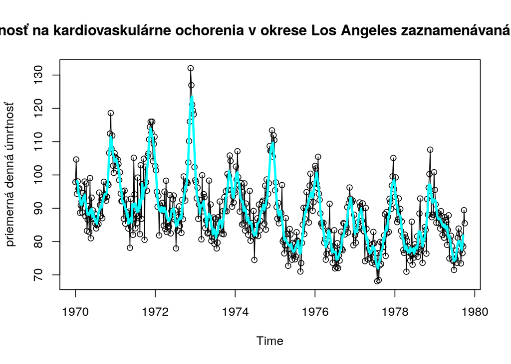

```r
klzavyPriemerKP5 <- filter(mortalityTS, filter = rep(1/5,5))
plot(mortalityTS, type = "o", main="Úmrtnosť na kardiovaskulárne ochorenia v okrese Los Angeles zaznamenávaná týždenne", ylab = "priemerná denná úmrtnosť")
lines(klzavyPriemerKP5, col='cyan', lwd=3)
```

Už to je menej roztrasené. Ale chceme odstrániť trendy. Keďže periodicita je 52, spravíme kĺzavy priemer rádu 53 (chceme nepárne číslo).

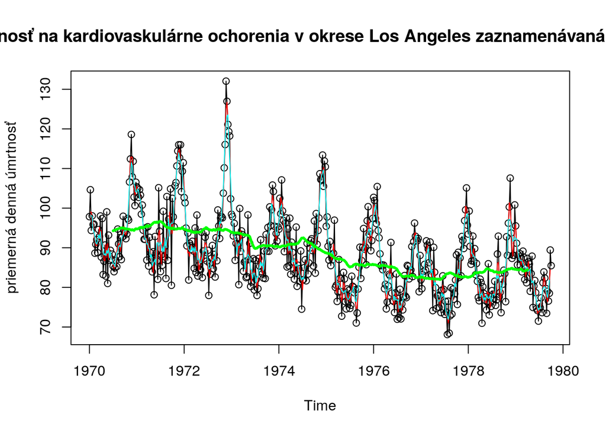

```r
klzavyPriemerKP53 <- filter(mortalityTS, filter = rep(1/53,53))
plot(mortalityTS, type = "o", main="Úmrtnosť na kardiovaskulárne ochorenia v okrese Los Angeles zaznamenávaná týždenne", ylab = "priemerná denná úmrtnosť")
lines(klzavyPriemerKP3, col='red', lwd=1)
lines(klzavyPriemerKP5, col='cyan', lwd=1)
lines(klzavyPriemerKP53, col='green', lwd=3)
```

Odstránili sme náhodnosť a sezónnosť. Ostal nám len trend. Kĺzavé priemery sú tiež veľmi dobré pri iných dátach ako napr. platy, hladiny nečistôt v ovzduší, atď.

#### Reziduá

Máme model:
$$X_t = m_t + S_t + \varepsilon_t$$
. Ak chceme len náhodné reziduá:
$$\varepsilon_t = X_t - (m_t + S_t)$$
. Časť $m_t + S_t$ je uložená v našom KP5. **POZOR** KP5 má menej hodnôt, treba na to pamätať.

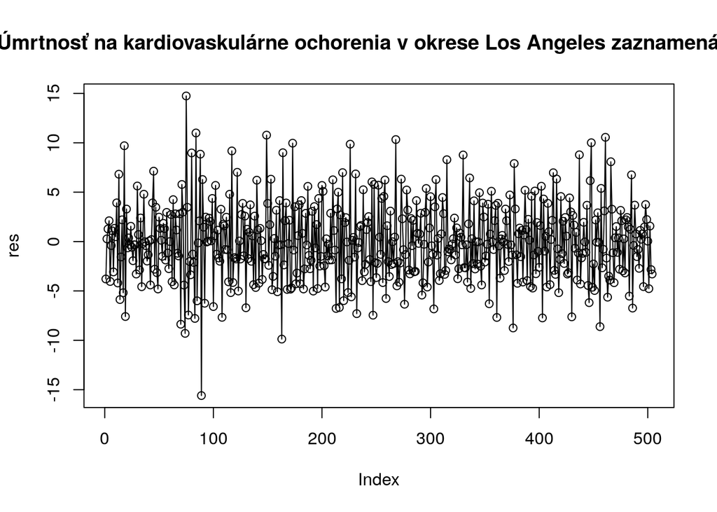

```r
reziduaMort = mortalityTS[3:506] - klzavyPriemerKP5[3:506]
plot(reziduaMort, type = "o", main="Reziduá - Úmrtnosť na kardiovaskulárne ochorenia v okrese Los Angeles zaznamenávaná týždenne", ylab = "res")
```

Teraz spravíme ACF a oba Box testy:

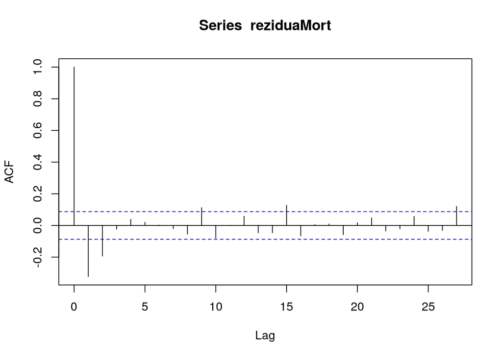

```r
acfMort <- acf(reziduaMort)
```

```r
Box.test(reziduaMort)
```

```
##
##  Box-Pierce test
##
## data:  reziduaMort
## X-squared = 52.538, df = 1, p-value = 4.22e-13
```

```r
Box.test(reziduaMort, type = 'Ljung')
```

```
##
##  Box-Ljung test
##
## data:  reziduaMort
## X-squared = 52.852, df = 1, p-value = 3.597e-13
```

Ešte stále dáte vyzerajú, že nie sú nezávislé. Z ACF sa domnievame, že sa dajú modelovať pomocou MA(1) alebo MA(2). Oba Box testy potvrdzujú, že nie sú nezávislé.

## Domáca

Uvažujme jednoduchý lineárny filter s váhami $\frac{1}{2q+1}$. Ukážte, že lineárny trend $m_t = c_0 + c_1t$ prejde cez filter nezmenený, t.j.
$$\frac{1}{2q+1}\sum_{j=-q}^{q}m_{t-j}=m_t$$